# Preliminary Rates

Geoff_Mayhew

2023-06-15

# Preliminary rates with a $4.5M budget

- ‘*FMP*’ means strata were additionally stratified by BSAI and GOA (by majority of retained catch). Separating the BS from the AI results in strata that are too small and was not evaluated here.
- ‘*Fixed*’ means all HAL and POT gear trips in the pools (monitoring method) were combined into fixed-gear stratum.
- ‘*Mixed*’ means we would have a separate stratum for trips fishing both HAL and POT gear, separate from trips that fish solely with HAL or POT gear.
- ’*(SQ)* refers to the status-quo application of the minimum+optimized allocation method where the EM strata are allocated at 30% or 1/3 using a carve-off of funds from the total monitoring budget. This is in contrast with the general application, *MPO*, that applies the allocatino algorithm to all strata.
- *(MPO 50)* is the older version of the status quo method that did not applies a 50% confidence level of achieving the 15% minimum (compared to the current 95% confidence level).
- ‘*(GS)*’, or *gear-specific*, means that interspersion was calculated in a gear-specific manner (applies to *Fixed* stratification schemes only), such that only trips with the same gear type were allowed to neighbor (contrasted with allowing POT and HAL trips in the same fixed-gear stratum to neighbor).

Notes:

- Monitoring-method-specific per day costs were assumed from the 2023 ADP and no assumptions were made about economy of scale, including the 2,000 day manimum of the current partial coverage observer contract. Those per-day costs were:
  - At-sea observer: $1,582.62
  - At-sea fixed-gear EM: $563.38
  - Shoreside observer: $600.00
- Within the proximity method, the CV-scaling portion of the index was left as-is for the *Fixed* stratification - that is, the total number of HAL and/or POT trips was used and not calculated in a gear-specific manner.

# Sample rates with allocations nested within stratifications

Select a stratification scheme and then an allocation scheme. The equal rates allocation scheme was only applied to the ‘Current’ stratification scheme. Note that the tabs remember which allocation scheme is selected within each stratification, so you can also compare how the same allocation method responds to changes in stratification.

## Current

### Equal Rates

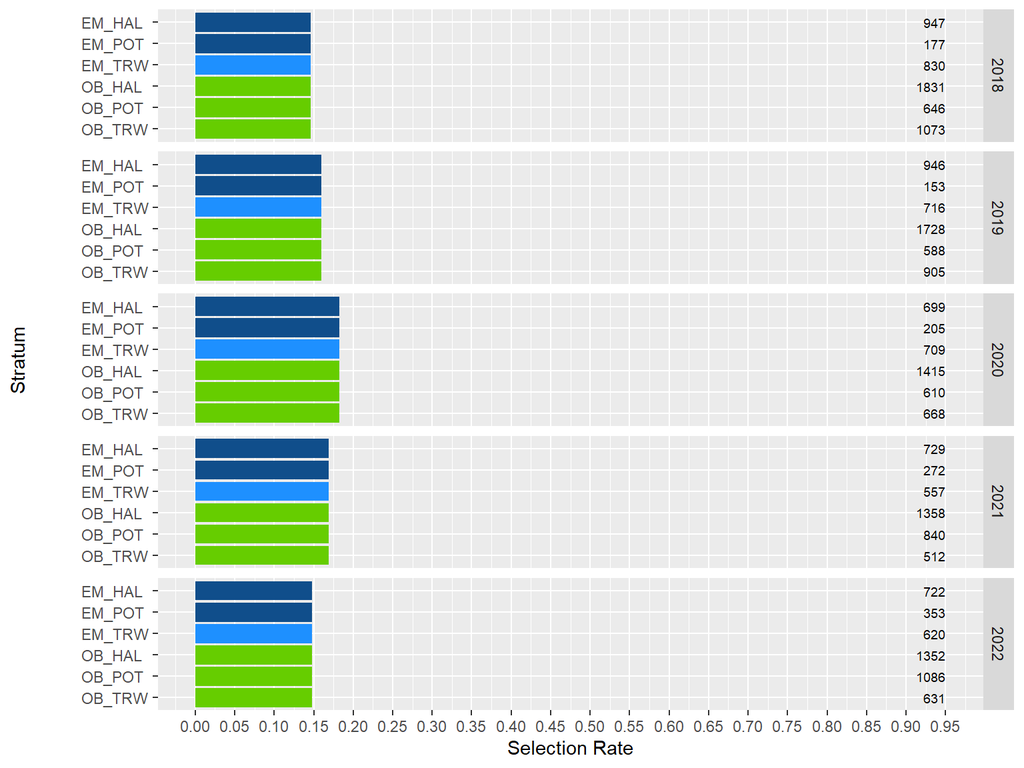

### MPO (SQ)

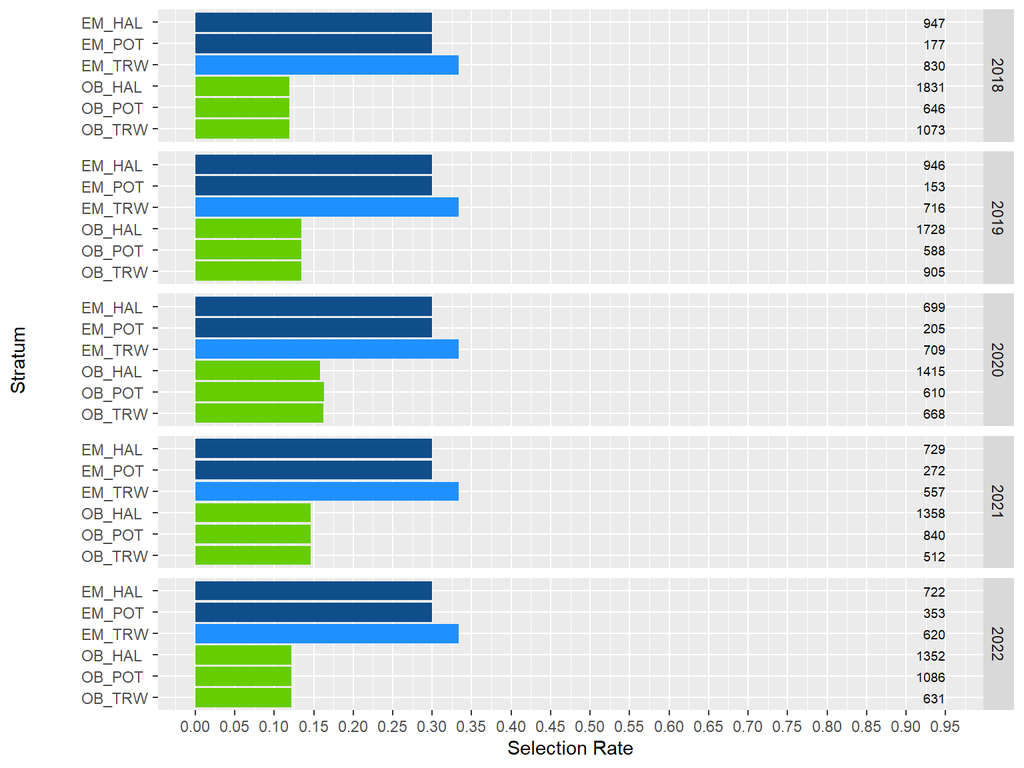

### MPO

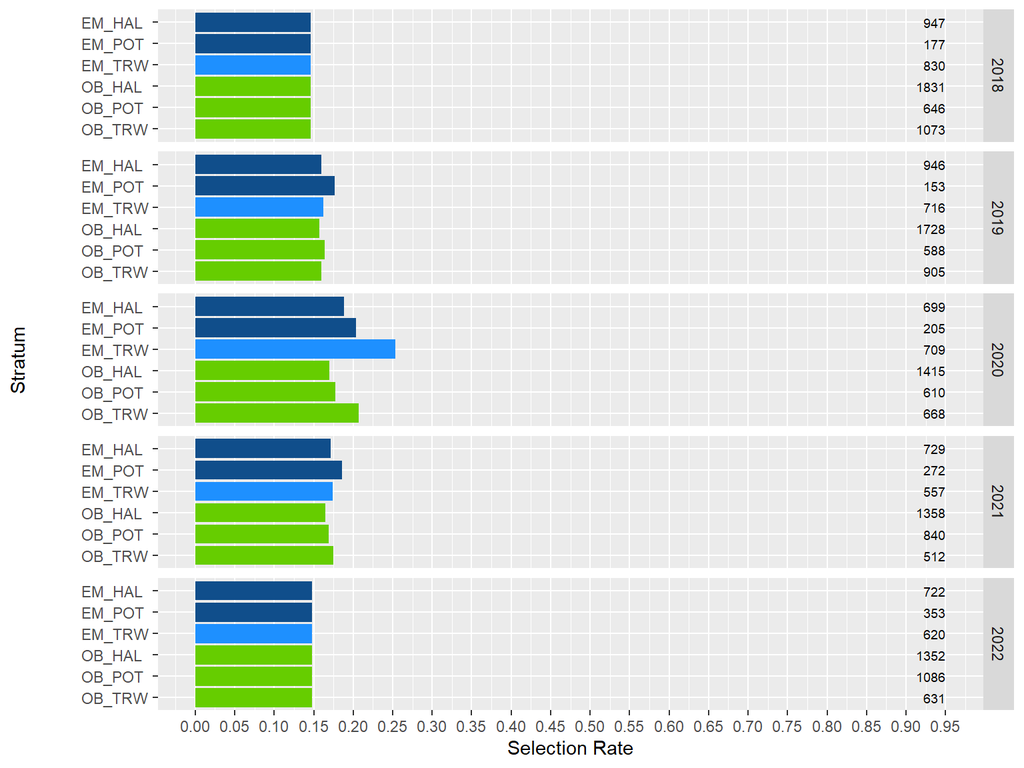

### MPO (50)

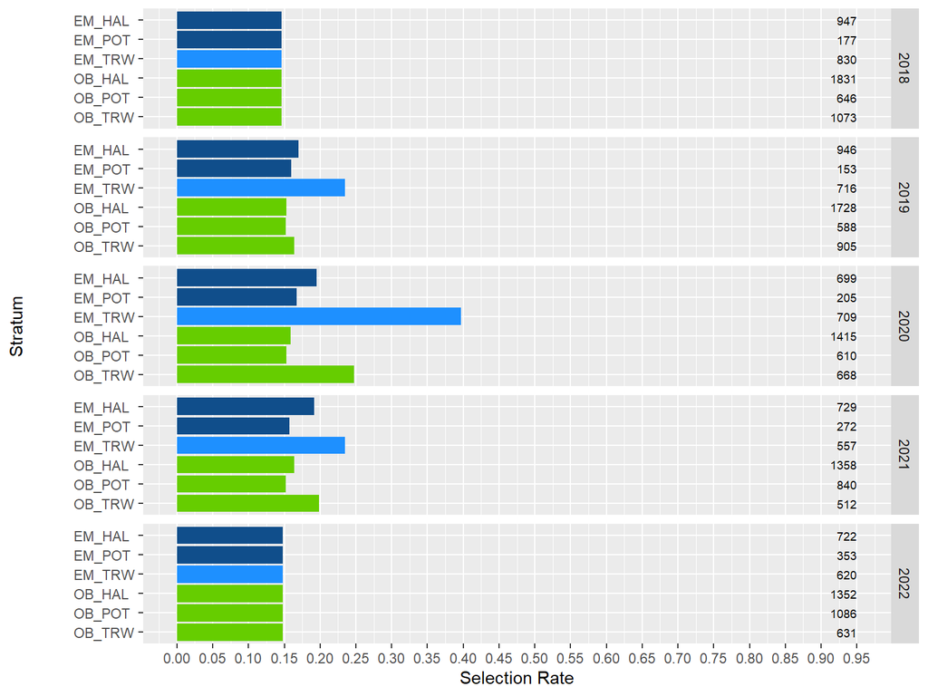

### CWB

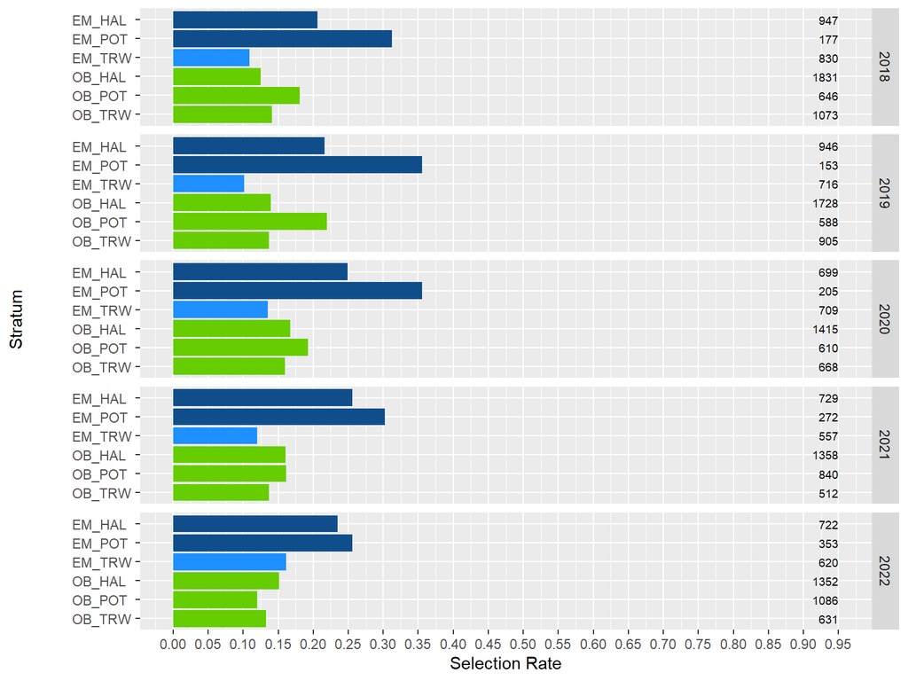

### PROX

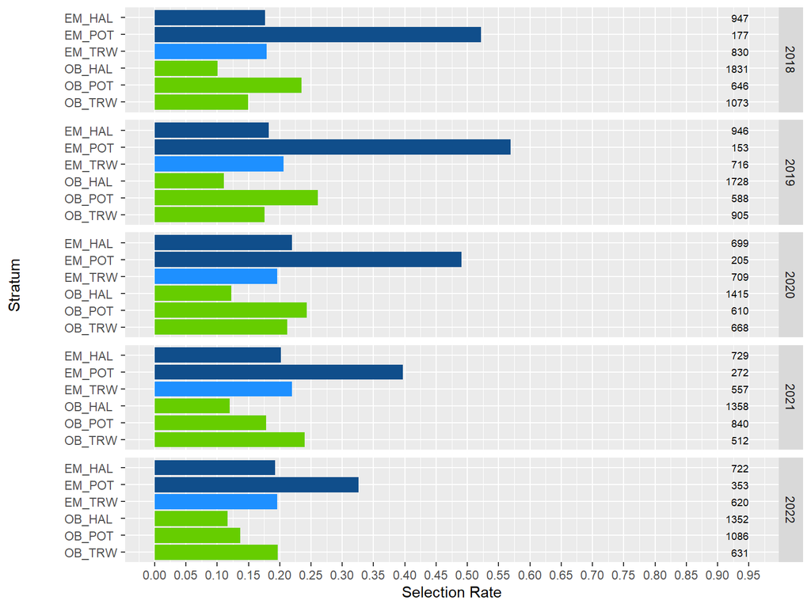

## FMP

### MPO (SQ)

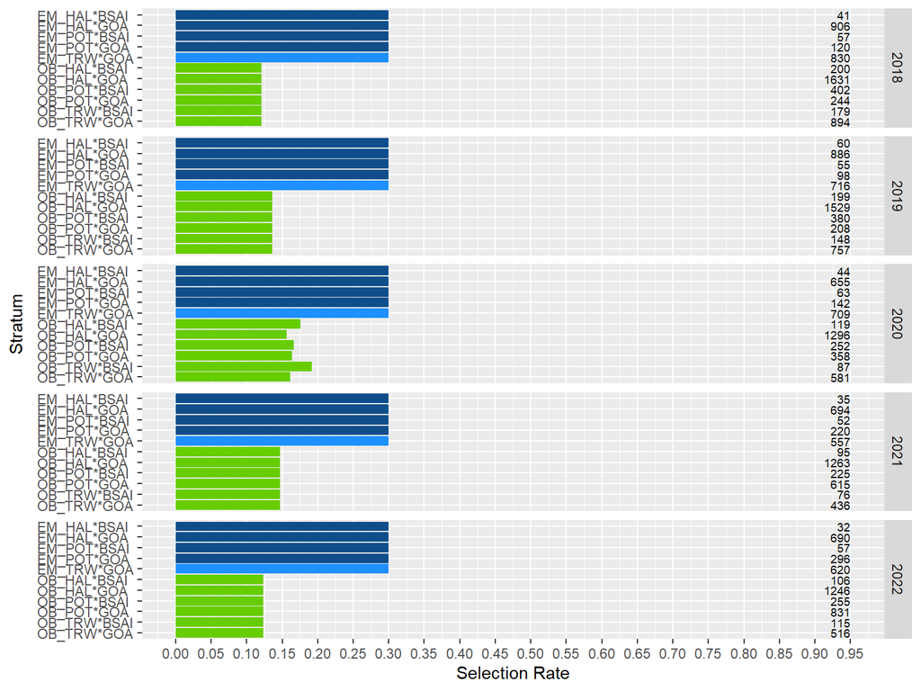

### MPO

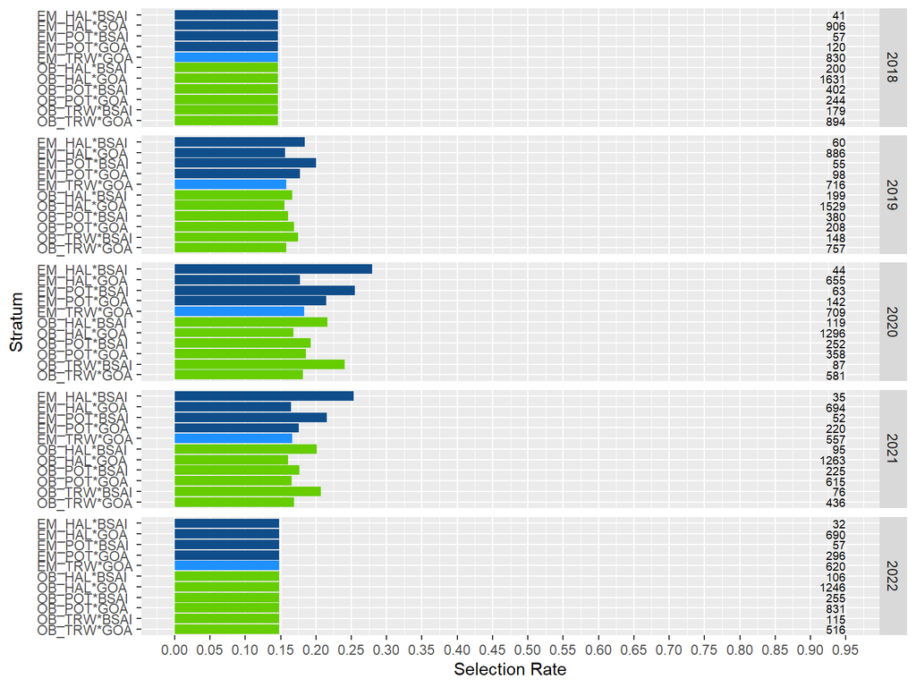

### MPO (50)

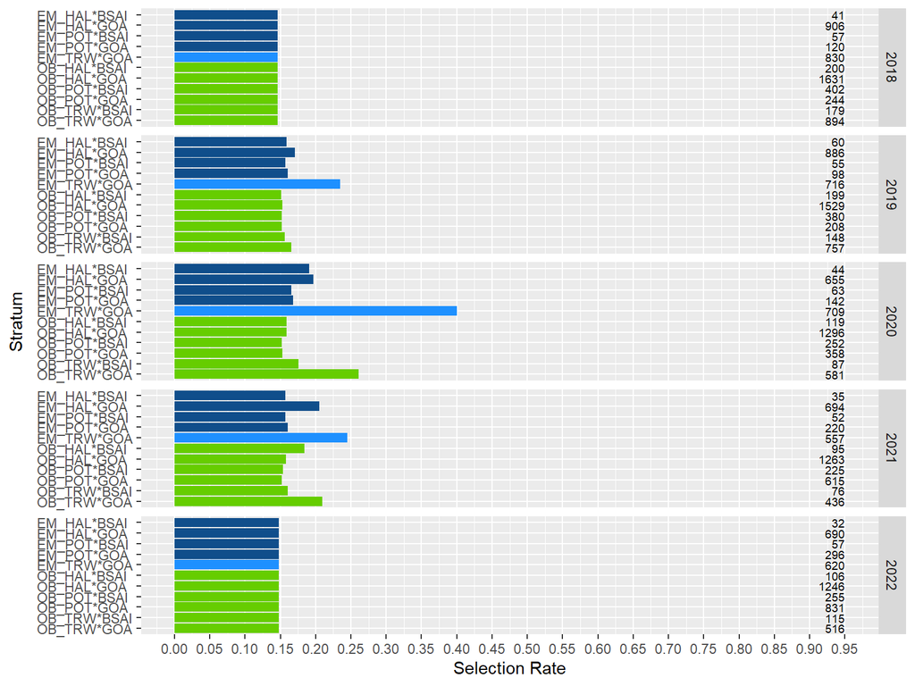

### CWB

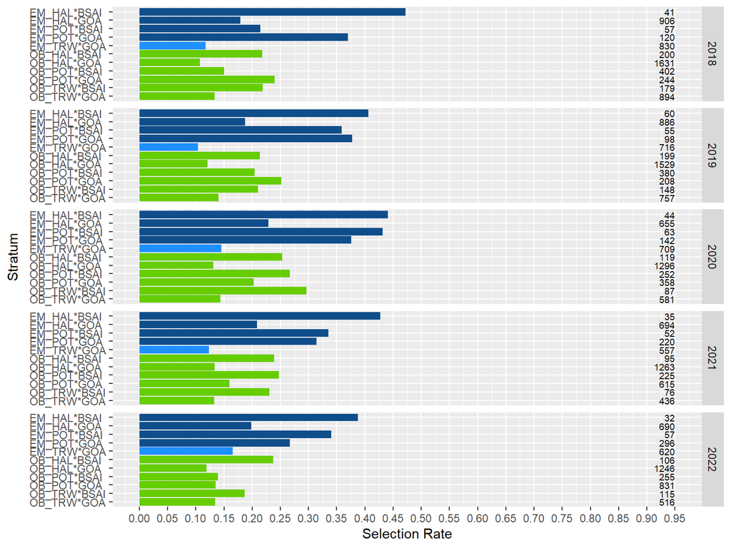

### PROX

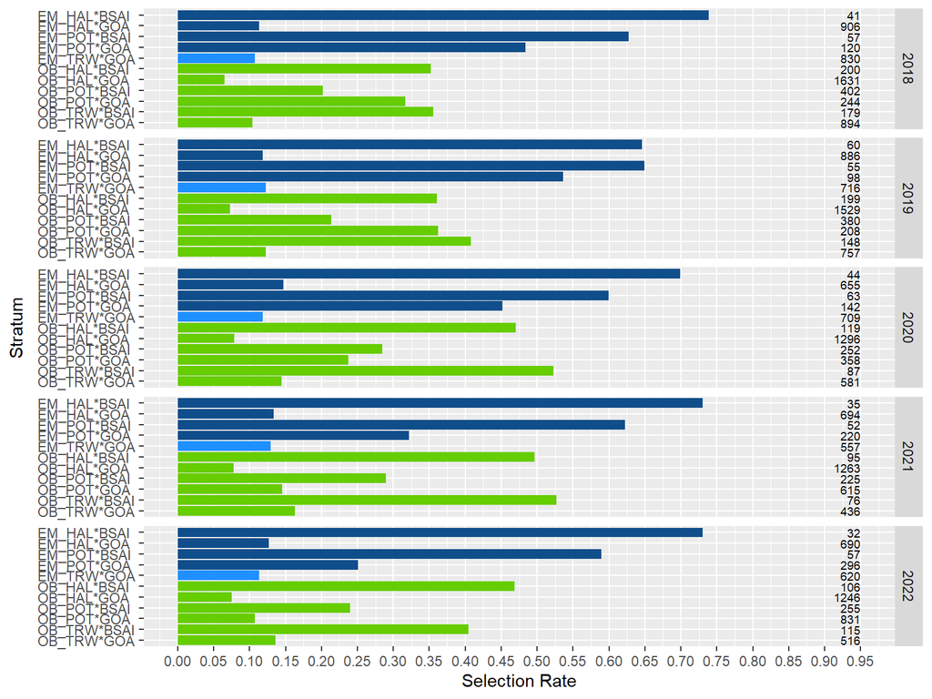

## Fixed

### MPO (SQ)

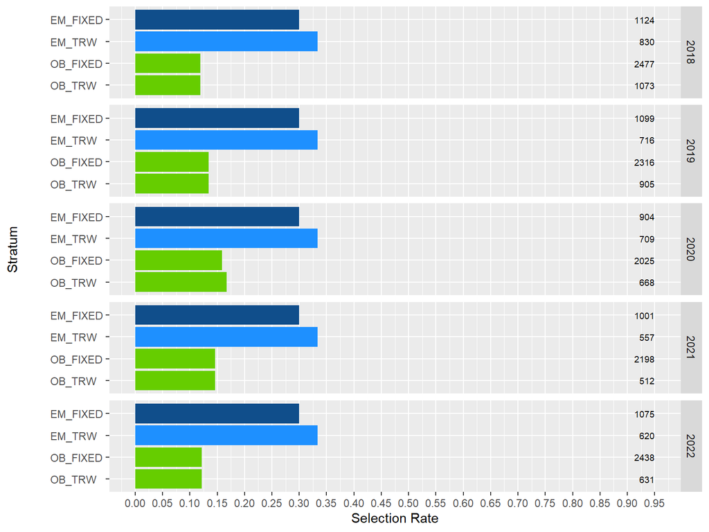

### MPO

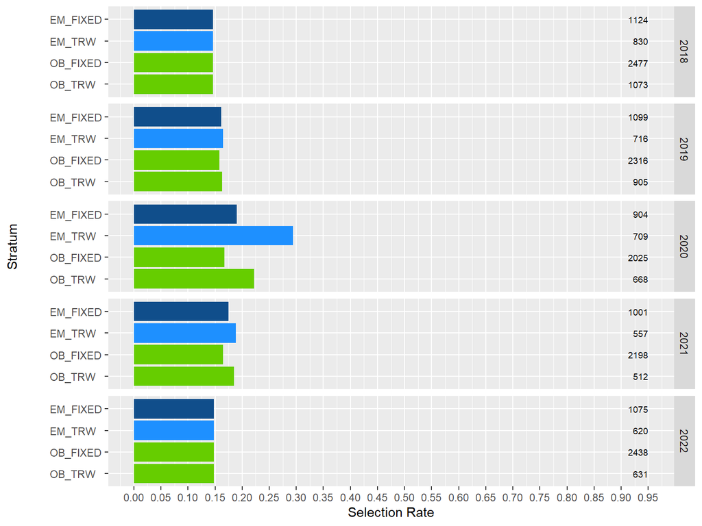

### CWB

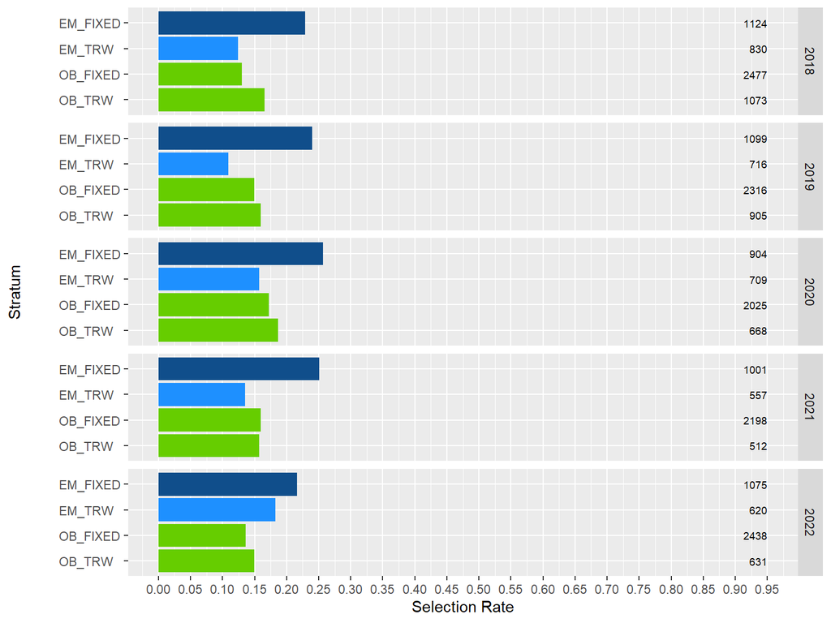

### CWB (GS)

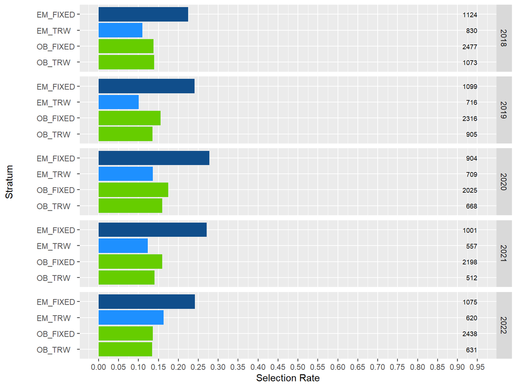

### PROX

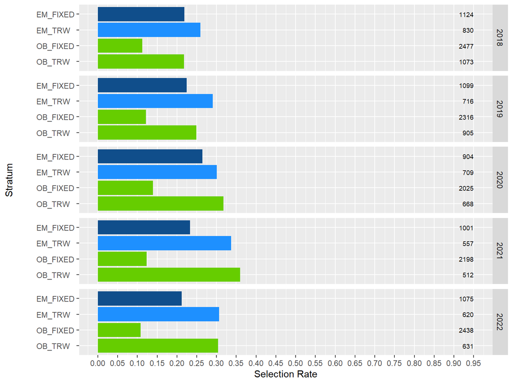

### PROX (GS)

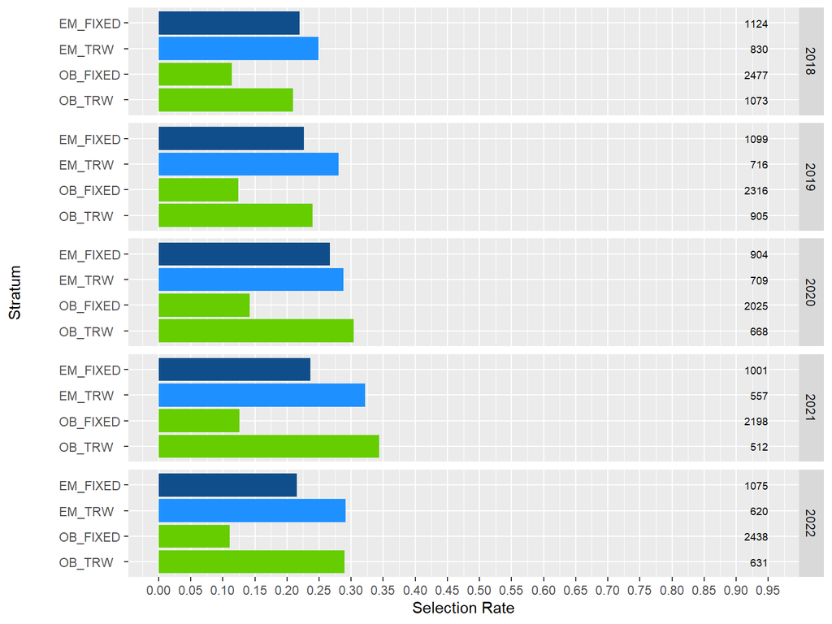

## Fixed FMP

### MPO (SQ)

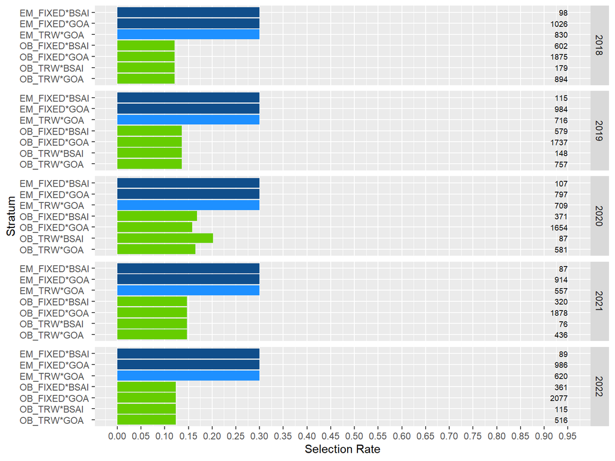

### MPO

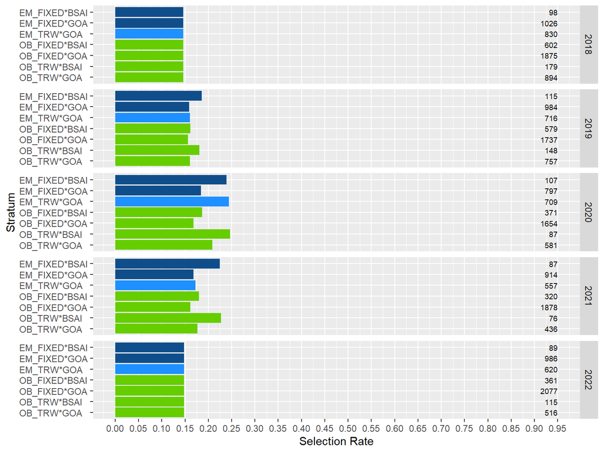

### CWB

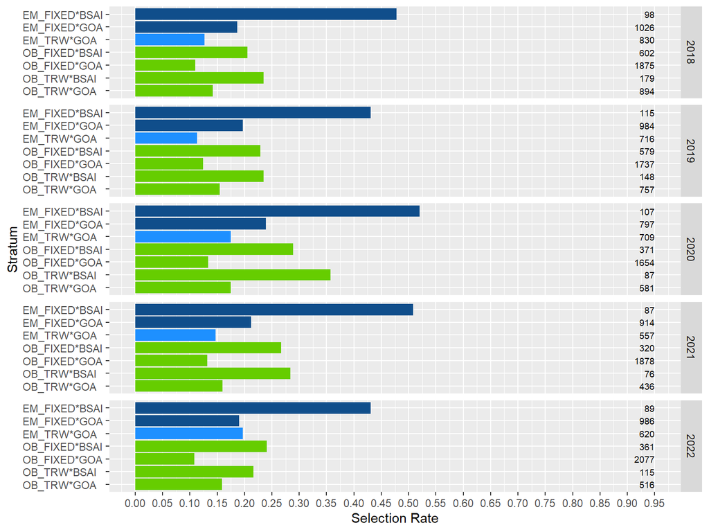

### CWB (GS)

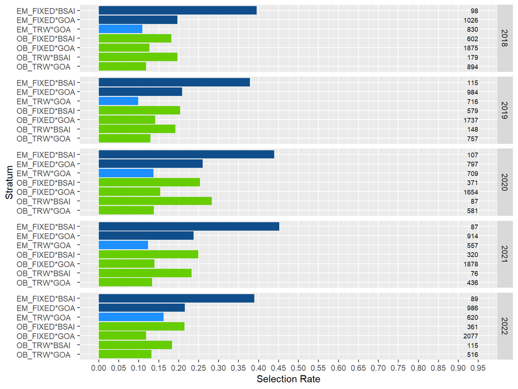

### PROX

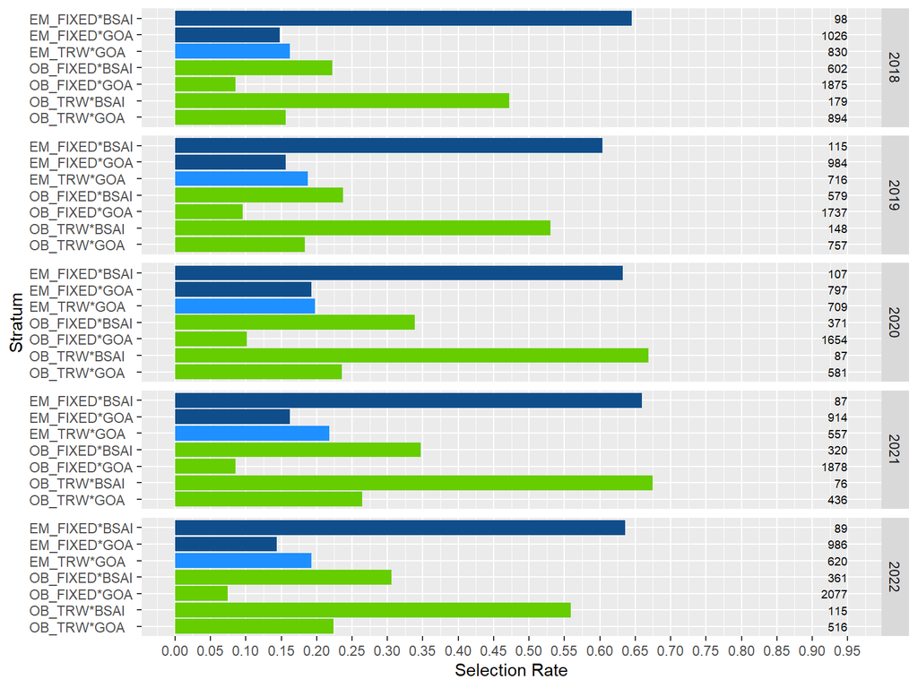

### PROX (GS)

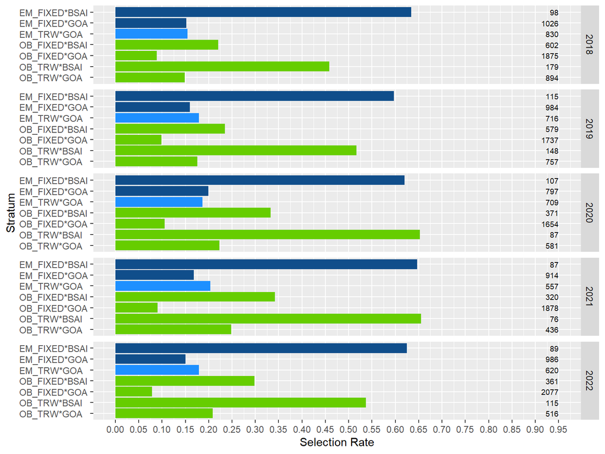

## Mixed

### MPO (SQ)

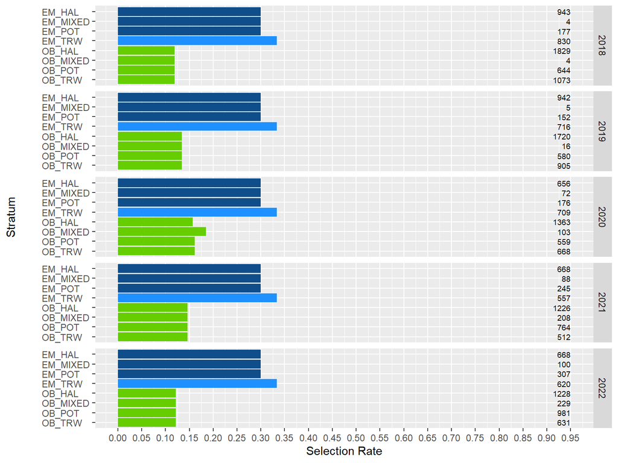

### MPO

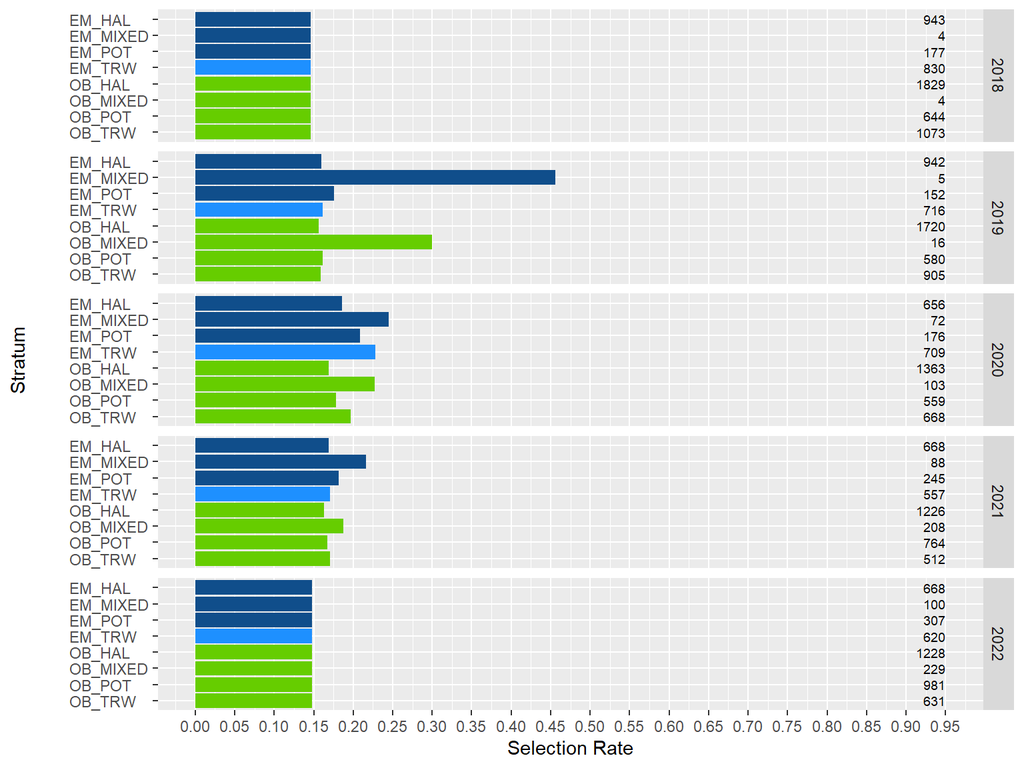

### CWB

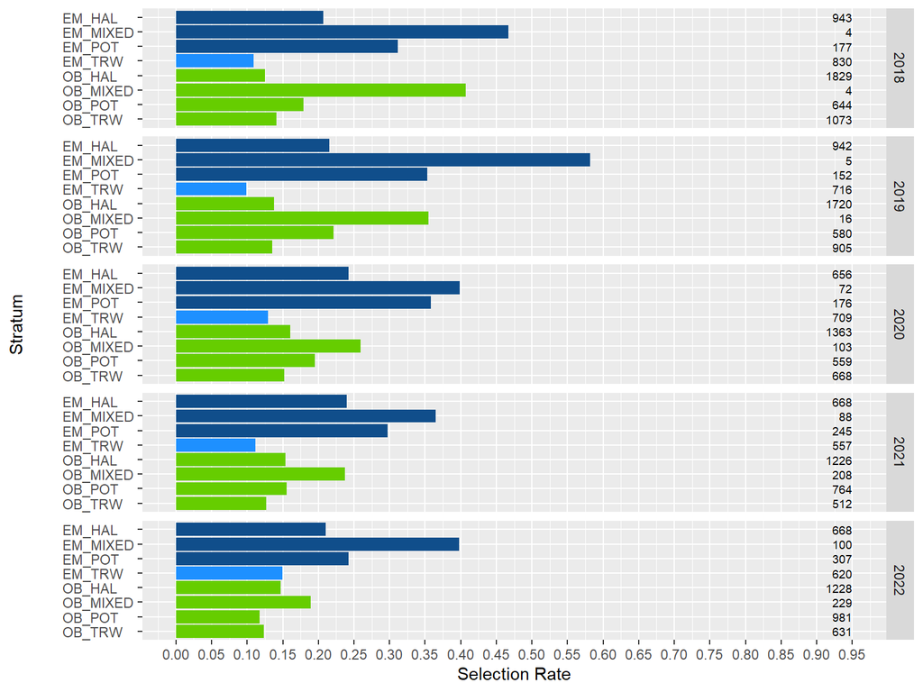

### PROX

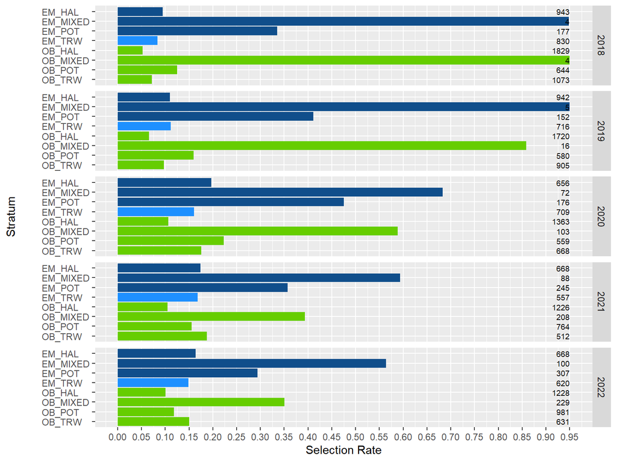

# Tabular form (In-progress)

## Equal

Applying equal rates to all strata. This was not repeated for all of our stratification variants.

## Min+Opt (status quo)

Applying the minimum + optimum allocation scheme to HAL, POT, and TRW strata only, carving off funds each year to achieve a 30% fixed-gear EM monitoring rate and a 1/3 shoreside sampling rate for EM_TRW. A 95% confidence level of achieving the 15% minimum was initially set. ‘*CONF*’ is either blank (reverted to equal rates), equal to 0.95 (achieved), or between 0 and 0.95 (the highest confidence level afforded). If the confidence level was achieved, the number of ‘optimized trips’ (‘*OPT_N*’) are given.

### Current

### BSAI_GOA

### Fixed

### Fixed + BSAI_GOA

## Min+Opt (for all strata)

Applying the minimum + optimum allocation scheme to all strata (including fixed-gear EM and trawl EM). Again, a 95% confidence level of achieving the 15% minimum was initially set. ‘*CONF*’ is either blank (reverted to equal rates), equal to 0.95 (achieved), or between 0 and 0.95 (the highest confidence level afforded)

### Current

### BSAI_GOA

### Fixed

### Fixed + BSAI_GOA

## Cost-Weighted Boxes

‘*fh*’ is the selection rate allocated. ‘*SAMPLE_RATE*’ is the sample rate that is assumed beforehand to determine *Ph* (the proportion of boxes expected to NOT to be neighboring a sampled trip), and should be very close to *fh*.

### Current

### BSAI_GOA

### Fixed

### Fixed + BSAI_GOA

## Proximity

‘*ISPN*’ is the proportino of trips in the stratum neighboring a monitored trip (*sum_pw* / *STRATA_N*). ‘*sum_pw*’ is the expected number of trips in the stratum neighboring a monitored trip. ‘*INDEX*’ = *ISPN* / *CV_SCALING* (not always exact, bust the closest within a 0.0001 change in monitoring rate).

### Current

### BSAI_GOA

### Fixed

### Fixed (gear-specific)

### Fixed + BSAI_GOA

### Fixed + BSAI_GOA (gear-specific)

# Still in progress

- Running these rates through the domain interspersion evaluation (deterministic version).